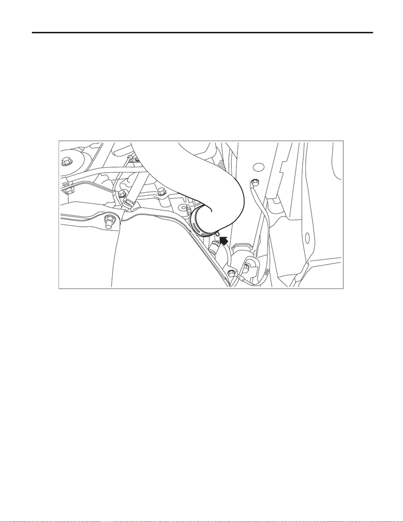

CO(w/o STI)-37

Radiator

COOLING

7. Radiator

A: REMOVAL

CAUTION:

The radiator is pressurized when the engine and radiator are hot. Wait until engine and radiator cool

down before working on the radiator.

1) Disconnect the ground terminal from battery sensor. <Ref. to NT-5, BATTERY, NOTE, Note.>

2) Remove the air intake duct. <Ref. to IN(w/o STI)-22, REMOVAL, Air Intake Duct.>

3) Remove the reservoir tank. <Ref. to CO(w/o STI)-52, REMOVAL, Reservoir Tank.>

4) Drain engine coolant. <Ref. to CO(w/o STI)-13, DRAINING OF ENGINE COOLANT, REPLACEMENT,

Engine Coolant.>

5) Disconnect the radiator outlet hose from thermostat cover.

6) Lower the vehicle.

CO-03356

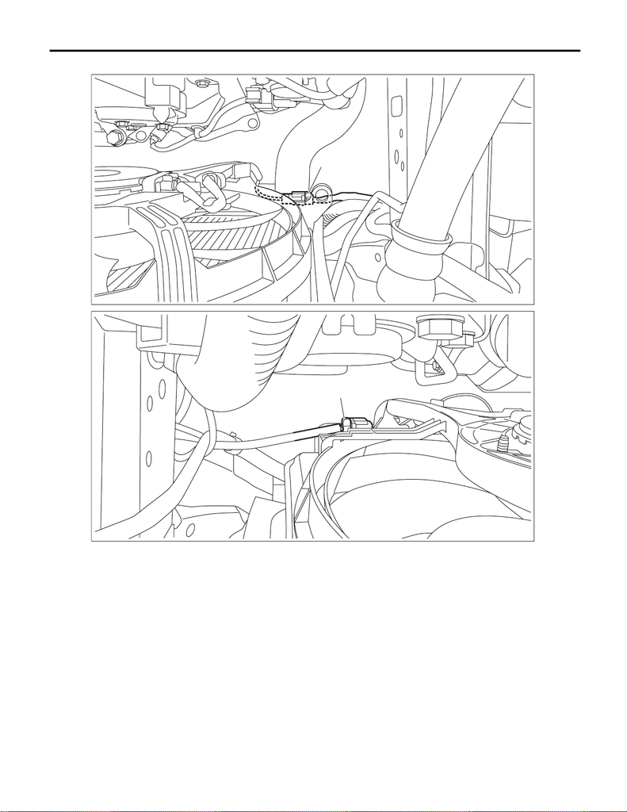

CO(w/o STI)-38

Radiator

COOLING

7) Disconnect the connector (A) from the main fan motor and the connector (B) from the sub fan motor.

CO-03167

(A)

CO-03168

(B)

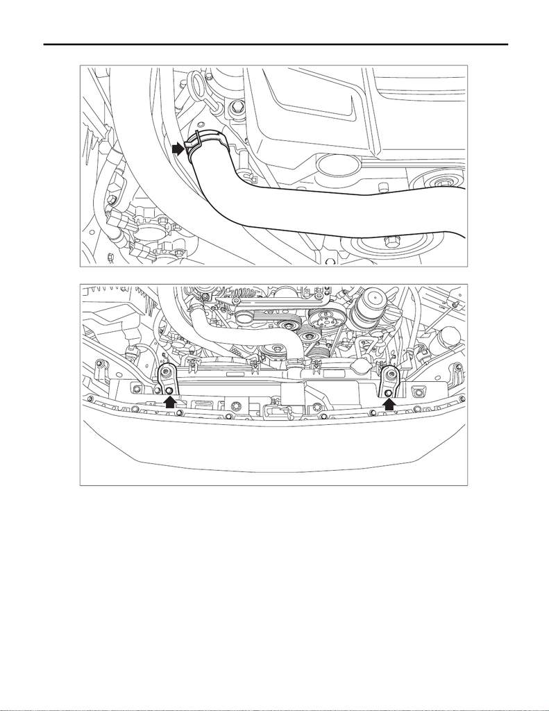

CO(w/o STI)-39

Radiator

COOLING

8) Disconnect the radiator inlet hose from the water tank pipe assembly.

9) Remove the radiator upper brackets.

10) Remove the radiator from vehicle.

CO-03361

CO-03360

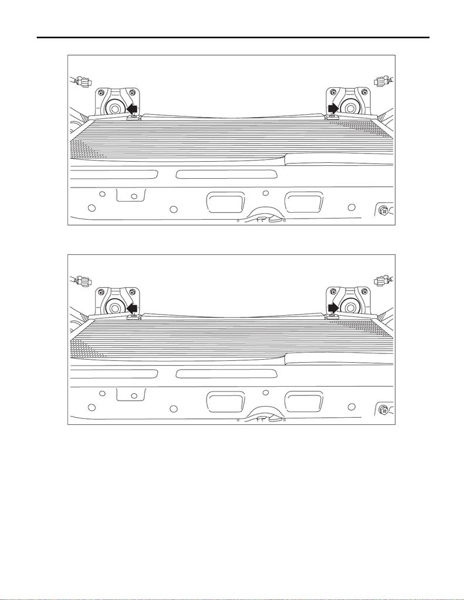

CO(w/o STI)-40

Radiator

COOLING

11) Remove the radiator lower cushion from the radiator lower bracket.

B: INSTALLATION

1) Attach the radiator lower cushion to the radiator lower bracket.

2) Install the radiator to vehicle.

NOTE:

Make pins on the lower side of radiator be fitted into the radiator lower cushions.

CO-03145

CO-03145

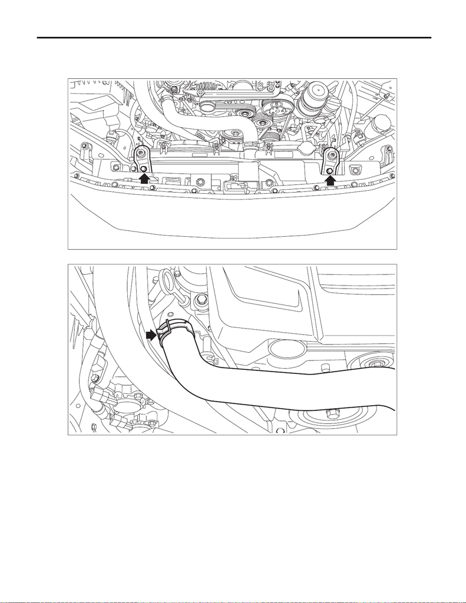

CO(w/o STI)-41

Radiator

COOLING

3) Install the radiator upper brackets.

Tightening torque:

12 N·m (1.2 kgf-m, 8.9 ft-lb)

4) Connect the radiator inlet hose to the water tank pipe assembly.

CO-03360

CO-03361

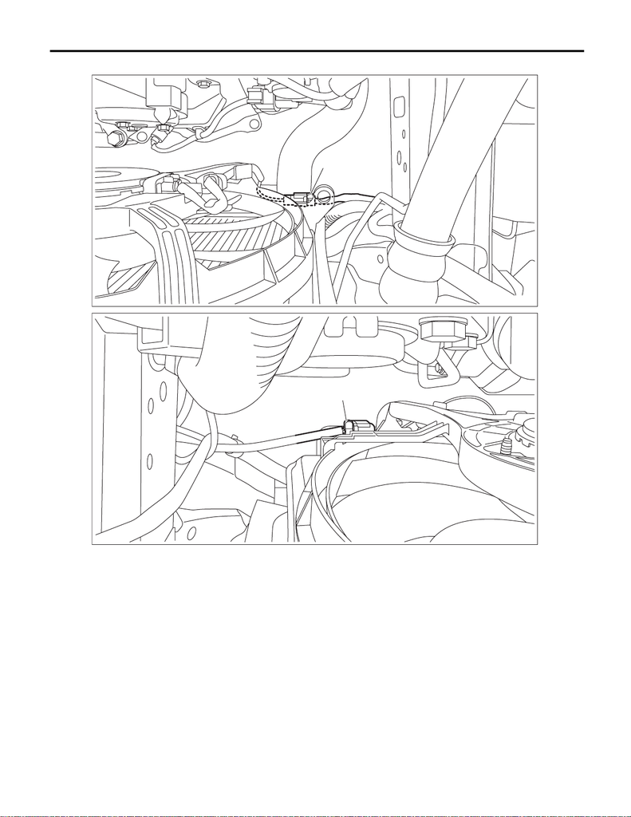

CO(w/o STI)-42

Radiator

COOLING

5) Connect the connector (A) to the main fan motor and the connector (B) to the sub fan motor.

6) Lift up the vehicle.

CO-03167

(A)

CO-03168

(B)

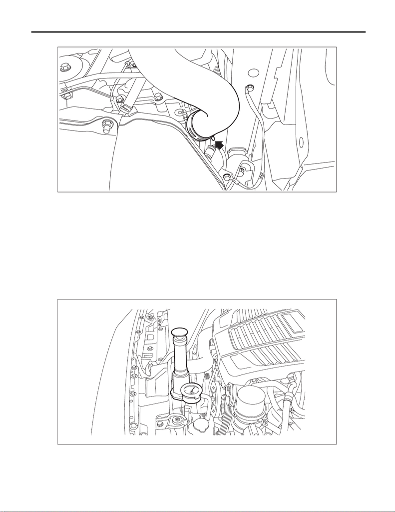

CO(w/o STI)-43

Radiator

COOLING

7) Connect the radiator outlet hose to thermostat cover.

8) Install the under cover. <Ref. to EI-22, INSTALLATION, Front Under Cover.>

9) Lower the vehicle.

10) Install the reservoir tank. <Ref. to CO(w/o STI)-52, INSTALLATION, Reservoir Tank.>

11) Install the air intake duct. <Ref. to IN(w/o STI)-22, INSTALLATION, Air Intake Duct.>

12) Connect the ground terminal to battery sensor. <Ref. to NT-5, BATTERY, NOTE, Note.>

13) Fill engine coolant. <Ref. to CO(w/o STI)-14, FILLING OF ENGINE COOLANT, REPLACEMENT, En-

gine Coolant.>

C: INSPECTION

1) Check that the radiator does not have deformation, cracks or damage.

2) Check that the hose has no cracks, damage or loose part.

3) Remove the radiator cap, fill the radiator with engine coolant, and then install the radiator cap tester to the

filler neck of radiator.

CO-03356

CO-03366

[figure not shown]

CO(w/o STI)-44

Radiator

COOLING

4) Apply a pressure of 157 kPa (1.6 kg/cm

2

, 23 psi) to the radiator and check the following points:

CAUTION:

• Engine should be turned off.

• Clean the check points.

• Be careful not to deform the filler neck of radiator when installing and removing the radiator cap

tester.

• Be careful of engine coolant from spurting out when removing the radiator cap tester.

• Leakage from the radiator or its vicinity

• Leakage from the hose or its connections